# Typing Game Kit Documentation

Send an email to support@tediuminteractive.com if you have any questions.

## Overview

Typing Game Kit provides a framework for creating typing games. In a typing game sequences of text appear on the screen that they player has to type in order to make progress. This framework defines how the sequences of text are displayed and how they respond to keyboard input.

For instance, in the example game Asteroid Typing the player shoots laser beams at asteroids by typing various words. Each asteroid is associated with a text sequence. The sequences are displayed on top of each asteroid. At any time at most one sequence is targeted and receives keyboard input. A sequences becomes targeted when it’s initial character is typed and no other sequence is already targeted. When a targeted sequence receives matching input the ship fires upon the corresponding asteroid. When a sequence has received all of it’s required input the associated asteroid will explode and the sequence will be removed. Thus, the more swiftly the player can type the longer their ship will survive.

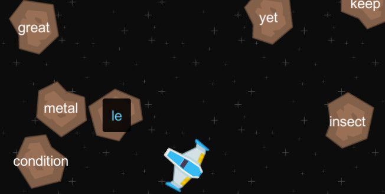

Asteroid Typing in action.

## Example Scenes

### Basic Setup

The basic setup scene contains a very simple example of how the Typing Game Kit in action. In this example words will appear on the screen and once a word has been typed another one will appear. This is a good place to start getting acquainted with how Typing Game Kit manages sequences.

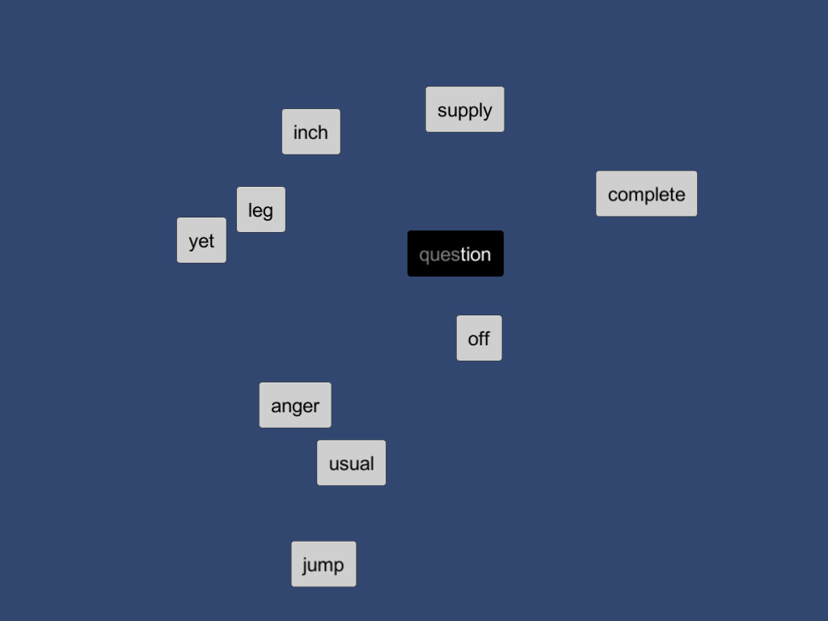

basic setup

### Interactive Demo

The interactive demo allows the user to experiment with some functionality of Typing Game Kit.

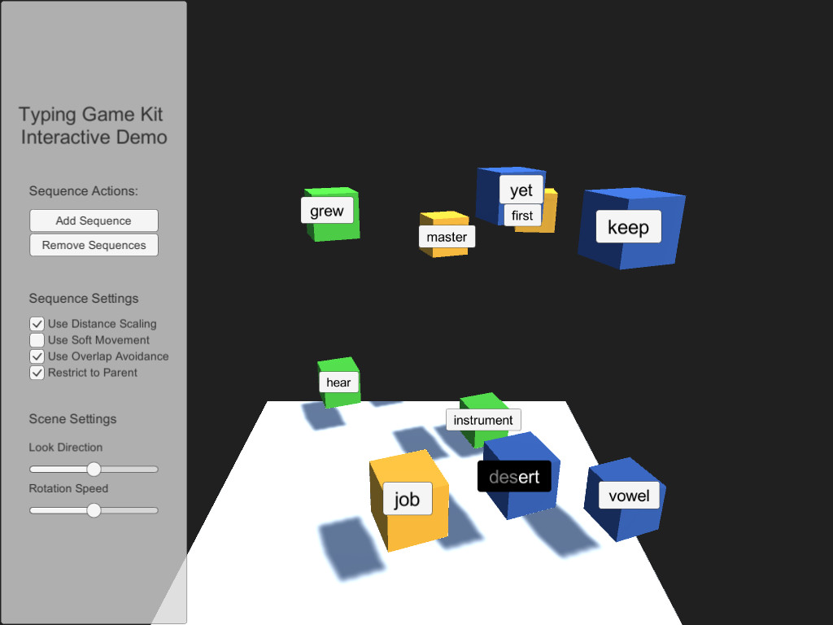

interactive demo

### Asteroid Typing

This example illustrates the implementation of a simple top down typing game. Asteroid will be flung at the player ship and the player may shoot at the asteroids in order to survive.

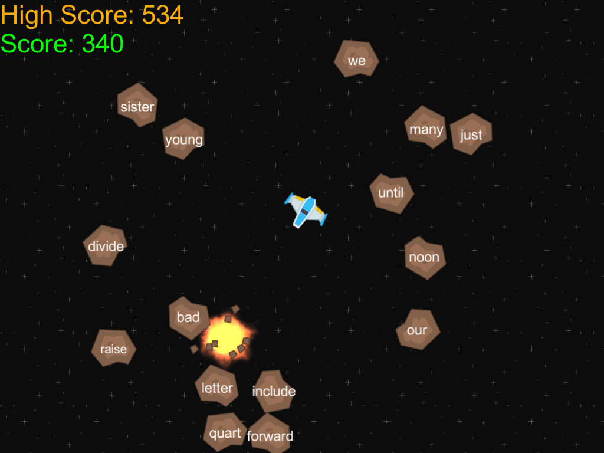

asteroid typing

### Alien Typing

Alien Typing demonstrates the implementation of a first person typing game. The player moves through a space ship and shoots at hostile aliens as they approach.

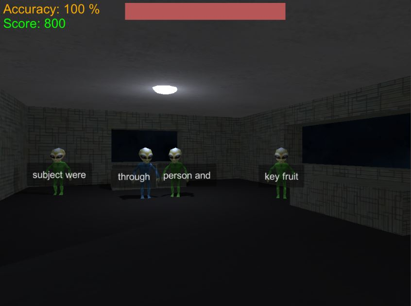

alien typing

## Important Concepts and MonoBehaviours

The sequences are displayed in an overlay canvas and are managed by a sequence manager.

### The SequenceManager

The `SequenceManager` is a `MonoBehaviour` that is attached to a object inside a canvas with the `Screen Space - Overlay` rendering mode enabled. The `SequenceManager` manages the creation and display of text sequences. Instantiated sequences will be children of the sequence manager.

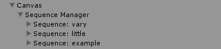

Sequence manager in the scene hierarchy.

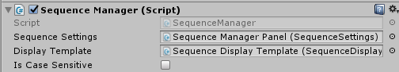

A sequence manager component.

The SequenceManager has a three of attributes:

- The **Sequence Settings** which specifies the sequences movement and visuals.
- The **Display Template** is a prefab that implements the sequence’s visuals.
- The **Is Case Sensitive** toggle determines if the case of input matters.

The `SequenceManager` should to be inside a `Canvas` with the `Screen Space - Overlay` rendering mode in order to function properly.

### The SequenceSettings

The `SequenceSettings` is a component that contains various settings governing the display and movement of sequences.

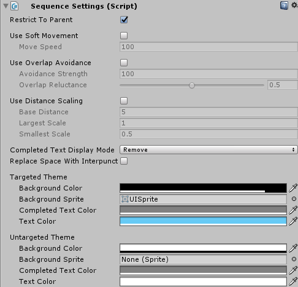

A sequence settings component

The settings are listed and described below:

- **Restrict to Parent**

  If this setting is toggled the sequence will be restricted to it’s manager’s `RectTransform`
- **Soft movement** If toggled sequences will move towards it’s anchored position over time instead of instantly “teleporting” to it’s corresponding position.
  - **MoveSpeed** determines the movement speed.
- **Overlap Avoidance**

  If toggled sequences will try to separate if they are overlapping.
  - **Avoidance Strength -** The strength of the overlap repulsion.
  - **Overlap Reluctance -** The relative distance at which sequences are repulsed from each other.
- **Distance Scaling**

  If distance scaling is enabled the size of the sequences are determined by their distance from the camera.
  - **Base Distance -** The distance from the camera at which a sequence has it’s default scale.
  - **Largest Scale -** Defines the largest allowable scale.
  - **Smallest Scale -** Defines the smallest allowable scale.
- **Completed Text Display mode**

  This setting defines how satisfied input is displayed in the sequence.
  - **Colorize -** The completed text will be colored according to the theme.
  - **Remove -** The completed text will not be shown.
- **Replace Space With Interpunct**

  If this settings is toggled spaces will be displayed with an interpunct (‘·’) when they are the required input.
- **Targeted Theme and Untargeted Theme**

  These two settings defines the color scheme of the sequence when it is targeted and untargeted respectively.
  - **Background Color -** The background color.
  - **Background Sprite -** The sprite to use as the background.
  - **Completed Text Color -** Color to use when displaying completed text.
  - **Text Color Color -** Default text color.

### The SequenceDisplay

The **SequenceDisplay** component is attached to an object that implements how the sequence looks in the canvas. This is the object to modify if you want to change the font, pivot, or animations of the sequences.

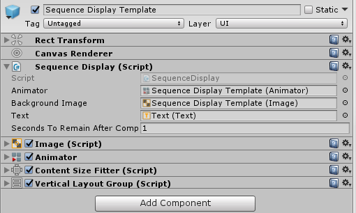

sequence display

### The StringCollection

A string collection can be created to facilitate the selection of strings to put into sequences. The strings in a string collection are gathered from each line among it’s text sources.

[figure not shown]

string collection

For instance we can pick a random string from a collection like this:

```csharp
string selectedText = stringCollection.PickRandomString();
```

However, generally we want to select some text that is uniquely selectable among other existing sequences. We can do this by passing a string collection to the sequence manager’s `GetUniquelyTargetableString` method:

```csharp
string selectedText = sequenceManager.GetUniquelyTargetableString(wordCollection);

// Caution! GetUniquelyTargetableString could return null!
// Let's pick a random word if that is the case.
selectedText = selectedText ?? stringCollection.PickRandomString();
```

A `StringCollection` is a `ScriptableObject` and can be created from the Assets/Create menu.

### The Default Prefabs

Prefabs for the `SequenceManager`, `SequenceDisplay`, and `SequenceSettings` can be found in the `/Typing Game Kit/Assets/Prefabs/` folder.

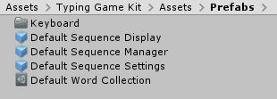

The default prefabs.

In the `Keyboard` sub-folder a virtual keyboard prefab resides which can be used to make the game playable on mobile devices.

## Managing Sequences

### Creating Sequences

Sequences are created by calling the sequence manager’s `CreateSequence` method:

```csharp
InputSequence sequence = sequenceManager.CreateSequence(text, anchor);
```

This will instantiate a sequence with the given text and anchor. The sequence position in the canvas will be matched with it’s anchor. `CreateSequence` returns a `InputSequence`. `InputSequence` is an interface which allows for interaction with a specific sequence.

View the Scripting Interface Overview section for an overview of the `InputSequence` and `SequenceManager` public interfaces.

### Listening to events

The `SequenceManager` and `InputSequence` defines a multitude events that can be listened to.

#### InputSequence events

The InputSequence’s events should be listened to if you want to respond to the events of an individual sequence.

For instance, in the Asteroid Typing example a sequence is created and attached to an asteroid like this:

```csharp
private void AttachSequenceToAsteroid(Asteroid asteroid)
{
    var sequence = sequenceManager.CreateSequence(GetNewSequenceText(), asteroid.transform);
    sequence.OnInputSucceeded += delegate { player.FireAt(asteroid); };
    sequence.OnCompleted += delegate { asteroid.Explode(); };
}
```

In this example, we listen to `OnInputSucceeded` to fire at an asteroid. Similarly we listen to `OnCompleted` to destroy an asteroid.

The sequence sending an event passes itself to it’s listener and the listener’s signature must be compatible with `System.Action<InputSequence>`.

#### SequenceManager events

The SequenceManager’s events should be listened to if you want to respond to the events of any sequence.

For example in Asteroid Typing the player’s score is tracked by listening to SequenceManager events:

```csharp
private void ListenToInputEvents()
{
    sequenceManager.OnInputSucceeded += CorrectInputReceived;
    sequenceManager.OnInputFailed += IncorrectInputReceived;
    sequenceManager.OnSelectionFailed += IncorrectInputReceived;
}

private void CorrectInputReceived(SequenceManager manager)
{
  // handling correct input ...
}

private void IncorrectInputReceived(SequenceManager manager)
{
  // handling incorrect input...
}
```

In this example we listen to `OnInputFailed` and `OnSelectionFailed` in order to handle input mistakes. Similarly we listen to `OnInputSucceeded` in order to handle correct input.

The manager sending an event passes itself to it’s listener and the listener’s signature must be compatible with `System.Action<SequenceManager>`.

## Scripting Interface Overview

### TypingGameKit.InputSequence

An interface used interacting with a created sequence.

#### Events

- **OnCompleted**

  Raised when the sequence has been completed.
- **OnTargeted**

  Raised when the sequence has been targeted.
- **OnInputFailed**

  Raised when the sequence receives input that does not match.
- **OnRemoval**

  Raised when a sequence is set for removal.
- **OnInputSucceeded**

  Raised when the sequence receives matching input.

#### Properties

- **Manager**

  The sequence’s manager.
- **Text**

  Text associated with the sequence. Can be used to change the sequence’s required input.
- **WorldAnchor**

  The transform associated with the sequence. Can be used to change the sequence’s anchor.

#### Methods

- **Remove**

  Removes the sequence.
- **ResetProgress**

  Resets the progress of the sequence.

### TypingGameKit.SequenceManager

Instantiates and manages sequences.

#### Events

- **OnInputFailed**

  Called when input failed to match the targeted sequence
- **OnInputSucceeded**

  Called when input matched the targeted sequence
- **OnSelectionFailed**

  Called when input was given but no sequence is targeted and no input matches any sequence.
- **OnSequenceCompleted**

  Called when active sequence was completed.

#### Properties

- **DefaultSequenceSettings**

  The SequenceSetting used for newly created sequences.
- **InputSequences**

  Returns all the current input sequences.
- **IsCaseSensitive**

  Determines if case of input is regarded when matching input to required sequence input.
- **LatestHandledInputChar**

  The latest input handled by the manager.
- **TargetedSequence**

  Returns the targeted sequence. Returns null if no sequence is targeted.
- **SequenceCount**

  Returns the number of managed sequences.

#### Methods

- **CreateSequence( System.String, UnityEngine.Transform )**

  Creates a new sequence with the provided text and anchor.
- **ClearTargetedSequence**

  Clears the targeted sequence.
- **GetUniquelyTargetableString( TypingGameKit.StringCollection )**

  Returns a string from collection that is uniquely targetable among the manager’s sequences. Returns null if no such string exists.
- **IsTextUniquelyTargetable( System.String )**

  Returns true if the text is uniquely targetable among the managers sequences.
- **RemoveAllSequences**

  Destroys all sequences.

### TypingGameKit.StringCollection

StringCollection provides a way to aggregate text strings.

#### Properties

- **StringDict**

  Dictionary that maps leading chars in lower case to corresponding strings in the StringCollection.
- **Strings**

  Array containing all strings in the collection.

#### Methods

- **EvaluateStrings**

  Reevaluates the strings and dictionary.
- **PickRandomString**

  Picks a string from the collection randomly.